# 輪読資料_構造的因果モデル

# 第2章 準備

## 2.1 因果推論における確率的考え方

データが大量に得られたとしても,そのデータから推測された統計モデルが物理的なデータ生成過程を適切に記述したものであることを,データだけを用いて保証する術を我々がもたない. このような不確実性を表現するために,構造的因果モデルのフレームワークでは,データ生成過程と確率・統計的な考え方が融合される.

## 2.2 事象の確率

### 試行(trials)

母集団からデータを採取するために行う実験や観測

### 確率試行(stochastic trial)

データを採取する場合,起こりうる結果の全体は概ね分かっているものの,そのなかのどれが観測できるのかを予め知ることができない場合の実験や観測のこと

### 標本空間(sample space),全事象(certain event)

確率試行を行った時に起こりうる結果.$\Omega$と書く.

### 事象(event)

標本空間の部分集合.$A,B,C,...$と書くことにする.  
和事象(union of events)$A \cap B$,積事象(intersection ゝ)$A \cup B$,差事象(difference ゝ),余事象(complement ゝ) $A^{c}$  
と書く.

### 空集合(empty event)

$\Omega$の要素を全く含まないもの. $\phi$と書く.

### 排反(disjoint,exclusive)

積事象$A \cap B$が空集合の場合.(集合の観点では,AとBは互いに素という)

### 確率の定義

ある事象$A$が起こる（$A$の要素が観測される）確率を$pr(A)$と表す.確率(probability)とは,標本空間$\Omega$の部分集合で定義された関数$pr(・)$で次の３つをみたすもの：
$$0 \leq pr(A) \leq 1 , A \subset \Omega \hspace{20pt} (2.2)$$
$$pr(\Omega) = 1 \hspace{20pt} (2.3)$$
$$AとBが排反であるならば \hspace{10pt} pr(A \cup B)=pr(A)+pr(B) \hspace{20pt} (2.4)$$
$(2.4)$から
$$pr(A) = pr((A \cap B)\cup(A \cap B^{c}))=pr(A \cap B)+pr(A \cap B^{c}) \hspace{20pt}(2.5)$$

### 全確率の公式(law of total probability)

もっと一般に,$B_{i}$$(i=1,2,...,n)$を互いに排反で標本空間$\Omega$を完全に分割する事象,$\Omega = B_{1} \cup ... \cup B_{n}$でかつ$i \neq j (i,j=1,...,n)$に対して積事象$B_{i} \cap B_{j}$が空集合となるような事象の集まりとする.この時

$$A=A \cap \Omega =A \cap (B_{1} \cup ... \cup B_{n}) = (A \cap B_{1})\cup...\cup(A \cap B_{n})\hspace{20pt} (2.6)$$
であるから,$pr(A)$は$pr(A \cap B_{i})(i=1,...,n)$を用いて

$$pr(A) = pr(A \cap \Omega) = pr((A \cap B_{1})\cup...\cup(A \cap B_{n})) = \sum_{i=1}^{n} pr(A \cap B_{i}) \hspace{20pt} (2.7)$$

### 周辺確率(marginal probability)

$(2.7)$より積事象$A \cap B$に対する確率$pr(A \cap B)$があたえられたとき,全ての$B_{i}$について確率を足し合わせることによって得られる確率$pr(A)$のこと.

$$pr(A) + pr(A^{c}) = 1 \hspace{20pt}(2.8)$$

### 条件付き確率(conditional probability)

ある事象が$B$が起こるという条件の下でもう一つの事象$A$が起こる確率$pr(A|B)$を考える.2つの事象$A$,$B$に対して,$pr(B)>0$であるとき
$$pr(A|B) = \frac{ pr(A \cap B)}{pr(B)} \hspace{20pt}(2.9)$$

### 乗法公式(product rule)

(2.9)より,$pr(A|B)$と$pr(B)$が与えられれば,積事象$pr(A \cap B)$の確率は
$$pr(A \cap B) = pr(A|B)pr(B) \hspace{20pt}(2.10) \\
pr(A \cap B) = pr(A|B)pr(B), pr(A \cap B) = pr(B|A)pr(A)\hspace{20pt}(2.11)$$
$pr(A \cap B)$にはその表現に一意性がない.

### 連鎖公式(chain rule)

また$n$個の事象$A_{1},...,A_{n}$があるとき乗法公式は,積事象$A_{1} \cap ... \cap A_{n}$の確率は条件付き確率の積として
$$pr(A_{1} \cap ... \cap A_{n}) = pr(A_{n}|A_{n-1} \cap ... \cap A_{1})...pr(A_{2}|A_{1}) \hspace{20pt}(2.12)$$
これはベイジアンネットワークの基礎となる.

$B_{i}(i=1,...,n)$を互いに排反で標本空間$\Omega$を完全に分割する事象の集まりであるとしよう.このとき,(2.7)と(2.10)より
$$pr(A) = \sum_{i=1}^{n} pr(A|B_{i})pr(B_{i}) \hspace{20pt} (2.13)$$

### 定義 2-1 事象の（周辺）独立性((marginal) independence)

2つの事象$A,B$に対して,
$$pr(A \cap B)=pr(A)pr(B) \hspace{20pt}(2.14)$$
が成り立つとき,事象$A$と$B$は（周辺）独立((marginally) independent)であるといい,$A \hspace{2pt} \!\perp\!\!\!\perp B$ と記す.

$pr(A \cap B) > 0$の過程のもとで,$A \hspace{2pt} \!\perp\!\!\!\perp B$であるとき$(2.9)$と$(2.14)$より
$$pr(A|B)=pr(A),\hspace{5pt}pr(B|A)=pr(B)\hspace{20pt}(2.15)$$
$(2.15)$のいずれか一つが成り立てば,$A \hspace{2pt} \!\perp\!\!\!\perp B$であることがいえる.
また,
$$A \hspace{2pt} \!\perp\!\!\!\perp B　ならば \hspace{6pt} A \hspace{2pt} \!\perp\!\!\!\perp B^{c},A^{c} \hspace{2pt} \!\perp\!\!\!\perp B,A^{c} \hspace{2pt} \!\perp\!\!\!\perp B^{c} \hspace{20pt} (2.16)$$
が成り立つ.

### 定義 2-2 事象の条件付き独立性(conditional independence)

3つの事象$A,B,C$に対して,
$$pr(A \cap B|C) = pr(A|C)pr(B|C) \hspace{20pt}(2.17)$$
が成り立つとき,事象$C$を与えたときに事象$A$と事象$B$は条件付き独立であるといい,$A \hspace{2pt} \!\perp\!\!\!\perp B|C$と記す.

$pr(A \cap B|C) > 0$の仮定のもとで,$(2.17)$が成り立つとき,(おそらく$(2.9)$と組み合わせて)
$$pr(A \cap B|C)= pr(A|C) , pr(B \cap A|C)= pr(B|C) \hspace{20pt}(2.18)$$
$(2.18)$に与えた式のうちいずれか1つが成り立つとき,$(2.17)$が導出できる.

以下2点が成り立つとは限らない.  
*$A \hspace{2pt} \!\perp\!\!\!\perp B|C$であれば$A \hspace{2pt} \!\perp\!\!\!\perp B|C^{c},A \hspace{2pt} \!\perp\!\!\!\perp B$*  
$A \hspace{2pt} \!\perp\!\!\!\perp B$あるいは$A \hspace{2pt} \!\perp\!\!\!\perp B|C^{c}$であれば,$A \hspace{2pt} \!\perp\!\!\!\perp B|C$

## 2.3 確率変数

標本空間 上で実数値関数を$X$など大文字を用いて表現,$X$が取りうる値全体からなる集合を$D_X$と表記する.

### 離散型確率変数(discrete random variable)

$D_x$が離散値の場合,$x \in D_X$のそれぞれに関して関数$pr(X=x)$は
$$pr(X=x) \geq 0 , \sum_{x} pr(X=x)=1 \hspace{20pt} (2.19)$$
$pr(X=x)$を確率関数(probability function)と呼ぶ.以降では$pr(x)$と記されていることも.
確率変数$X$の値がある集合$A \subset D_X$に入る確率は,
$$pr(X \in A) = \sum_{X \in A}pr(x) \hspace{20pt} (2.20)$$

### 累積分布関数(cumulative distribution function): 離散

$D_X$の要素に順序がついている場合,
$$pr(X \geq x)= \sum_{ t \geq x}pr(t) \hspace{20pt} (2.21)$$

### 連続値の場合

$D_X$が連続の時,$x \in D_X$に対して関数 $f_X(x) \geq 0$を
$$\begin{array}{||}
\int_{x} f_X(x)dx=1,pr(a<X \leq b)= \int_{a}^{b}f_X(x)dx \\
pr(X=a)=\int_a^a f_X(x)dx=0 \end{array} \hspace{20pt} (2.22)$$
$x$は$D_X$を積分範囲とする. $X$：連続型確率関数(continuous random variable),$f_X(x)$を$X$の確率密度関数(probability density function).

### 累積分布確率：連続

$$pr(X \leq x)= \int_{-\infty}^x f_X(t)dt \hspace{20pt} (2.23)$$

### $X$の平均(mean),期待値$E(X)$(expectation)

Xが離散型確率変数の場合
$$E(X)=\sum_x x \times pr(x) \hspace{20pt} (2.24)$$

Xが連続型確率変数の場合
$$E(X)=\int_x x \times f_X(x)dx \hspace{20pt} (2.25)$$

これを$\mu_x$と記す.

### 一般化した$X$の平均(mean),期待値$E(X)$(expectation)

$X$に関する関数$g(X)$に対して, Xが離散型確率変数の場合
$$E(g(X))=\sum_x g(x) \times pr(x) \hspace{20pt} (2.26)$$

Xが連続型確率変数の場合
$$E(g(X))=\int_x g(x) \times f_X(x)dx \hspace{20pt} (2.27)$$

$g(X)=(X-\mu_x)^{2}$とした場合,$(2.26),(2.27)$は$X$の分散(variance)であり,$var(X),\sigma_{xx}$と記す.

## 2.4 確率変数ベクトル

一つの確率変数のみから,多次元確率変数ベクトルへ拡張する.(といっても大体2.3と同じ) $\bf X =(X_1,...,X_p)'$  
をp次元確率変数ベクトル (p dimensional random vector)という.

### 集合

和集合(union) $\bf X \cup \bf Y$,積集合(intersection)$\bf X \cap \bf Y$,差集合(set difference)$\bf X \backslash \bf Y$と表す.  
演算の順序にしたがって$(・)$をつける.

### 確率関数の定義

同時確率密度関数(joint probability density function)$pr(X_1=x_1,...,X_p=x_p)$(簡略化のため$pr(\bf x)$,$pr(x_1,..,x_p)$と記す.) が0以上で,
$$\sum_{x_1,...,x_p}pr(X_1=x_1,...,X_p=x_p)=1 \hspace{20pt} (2.28)$$
を満たすように定義する. $D_{X_i}$に含まれる要素に順序がついている場合$(i=1,...,p)$,
$$pr(a_1 < X_1 \leq b_1,...,a_p< X_p \leq b_p)=\sum_{a_1 < X_1 \leq b_1,...,a_p< X_p \leq b_p}pr(x_1,...,x_p)\hspace{20pt} (2.29)$$
$(a_i,b_i \in D_X ; i=1,...,p)$.

### 累積同時分布関数

$$pr(X_1 \leq x_1,...,X_p \leq x_p)= \sum_{t_1 \leq x_1,...,t_p \leq x_p} pr(t_1,...,t_p) \hspace{20pt} (2.30)$$

### 周辺分布関数(marginal cumulative distribution function)

$$pr(X_i \leq x_i) = \sum_{x_1,...,x_{i-1}} \sum_{t_i \leq x_i} \sum_{x_{i+1},...,x_p} pr(x_1,...,x_{i-1},t_i,x_{i+1},...,x_p) \hspace{20pt} (2.31)$$

### 周辺確率密度関数(marginal density function)

$$pr(x_i) = \sum_{x_1,...,x_{i-1},x_{x+1},...,x_p} pr(x_1,...,x_p) \hspace{20pt}(2.32)$$

### 条件付き確率密度関数：ベクトル版

2つの確率変数の集合$\bf X$と$\bf Y$に対して,これらの要素からなる同時密度関数を$pr(\bf x,\bf y)$とすると,$pr(\bf x)>0$に対して
$$pr(\bf y|\bf x)= \frac{pr(\bf x,\bf y)}{pr(\bf x)} \hspace{20pt} (2.33)$$

### 乗法公式：ベクトル版

$(2.33)$より,$pr(\bf y｜\bf x)$と$pr(\bf x)$が与えられれば,$\bf X \cup \bf Y$の同時密度関数は$pr(\bf x,\bf y)$は,
$$pr(\bf x,\bf y)=pr(\bf y|\bf x)pr(\bf x) \hspace{20pt} (2.34)$$

確率変数ベクトルにおいても乗法公式の表現方法には一意性がなく以下の$(2.35)$の2通りの形式が存在する.

$$pr(\bf x,\bf y)=pr(\bf y|\bf x)pr(\bf x),pr(\bf x,\bf y)=pr(\bf x|\bf y)pr(\bf y) \hspace{20pt} (2.35)$$

### 同時密度関数の逐次的因数分解(recursive factorization) or 連鎖公式

乗法公式の拡張として,条件付き確率関数$pr(x_p|x_1,...,x_{p-1}),...,pr(x_2|x_1)$と周辺確率密度関数$pr(x_1)(これはpr(x_1|x_0))$が与えられている時,$pr(x_1,...,x_p)$に対して乗法公式を逐次的に適用することにより,
$$pr(x_1,...,x_p)=\prod_{i=1}^{p} pr(x_i|x1,...,x_{i-1}) \hspace{20pt}(2.36)$$
同時密度関数の逐次的因数分解に変数間の条件付き独立性を導入し,その構造を視覚的に表現したグラフの一つがベイジアンネットワークである.

### 定義 2-3 確率変数どうしの（周辺）独立性(marginal independence)

確率変数ベクトル$\bf X$と$\bf Y$の同時密度関数を$pr(\bf x,\bf y)$とおく,任意の$\bf x \in D_X$と任意の$\bf y \in D_Y$に対して,
$$pr(\bf x, \bf y)=pr(\bf x)pr(\bf y)\hspace{20pt}(2.37)$$
が成り立つ時,$\bf X$と$\bf Y$は（周辺）独立であるといい,$\bf X \hspace{2pt} \!\perp\!\!\!\perp \bf Y$と記す.

### 定義 2-1 と違う点

$2-1$は事象間の独立性である特定の事象に着目したものであるのに対して,$2-3$は$\bf X$と$\bf Y$の取りうる値全体に対して$(2.37)$が成り立つことを要請したもの.

$pr(\bf x, \bf y)>0$のもとで$\bf X \hspace{2pt} \!\perp\!\!\!\perp \bf Y$のとき,
$$pr(\bf x|\bf y)=pr(x),pr(\bf y|\bf x)=pr(y) \hspace{20pt}(2.38)$$

### 定義 2-4 確率変数どうしの条件付き独立性(conditional independence)

3つの確率変数$\bf X,\bf Y,\bf Z$に対して,$\bf Z=\bf z$を与えた時の$\bf X$と$\bf Y$の条件付き確率密度関数を
$$pr(\bf x,\bf y| \bf z)=pr(\bf x|\bf z)pr(\bf y|\bf z)\hspace{20pt}(2.39)$$

が成り立つ時,$\bf Z=\bf z$を与えた時に,$\bf X$と$\bf Y$は条件付き独立であるという.これを$\bf X \hspace{2pt} \!\perp\!\!\!\perp \bf Y|\bf Z=\bf z$と記す.特に,任意の$\bf Z=\bf z$に対して$(2.39)$が成り立つ時,$\bf Z$を与えた時に$\bf X$と$\bf Y$は条件付き独立であるといい,$\bf X \hspace{2pt} \!\perp\!\!\!\perp \bf Y|\bf Z$と記す.

$pr(\bf x, \bf y|\bf z)>0$の仮定のもとで$\bf Z= \bf z$を与えた時に$\bf X$と$\bf Y$が条件付き独立であるとき,$(2.39)$より,任意の$\bf x \in D_X$と$\bf y \in D_Y$に対して
$$pr(\bf y|\bf x,\bf z)=pr(\bf y|\bf z),pr(\bf x|\bf y,\bf z)=pr(\bf x|\bf z) \hspace{20pt}(2.40)$$
$(2.40)$のうちいずれか一つが成り立つなら,$\bf Z= \bf z$を与えた時に,$\bf X$と$\bf Y$が条件付き独立である.

### 条件付き平均(conditional mean),条件付き期待値(conditional expectation)

$\bf Y= \bf y$に関する関数$g(\bf y)$に対して$\bf X= \bf x$が与えられた時の条件付き平均あるいは条件付き期待値は,
$$E(g(\bf Y)|\bf X =\bf x)=\sum_{y}g(\bf y) \times pr(\bf y|\bf x)\hspace{20pt}(2.41)$$
$\bf Y$が単一変数$Y$である時,$g(Y)=Y$とおいた時,$(2.41)$は$\bf X= \bf x$を与えた時の$Y$の条件付き期待値,条件付き平均と言われ,これを$\mu_{y,x}$と記す. $g(Y)=(Y-\mu_{y.x})^2$とした時の$(2.41)$は,$\bf X= \bf x$を与えた時の$Y$の条件付き分散(conditional variance)と呼ばれ$var(Y|\bf X=\bf x)$または$\sigma_{yy.x}$と記す.

2つの変数$X$と$Y$からなる関数$g(X,Y)$の期待値$E(g(X,Y))$は同時密度関数$pr(x,y)$を用いて
$$E(g(X,Y))=\sum_{x,y}g(x,y) \times pr(x,y) \hspace{20pt}(2.42)$$
$\bf Z= \bf z$を与えた時の期待値
$$E(g(X,Y)|\bf Z=\bf z)= \sum_{x,y}g(x,y) \times pr(x,y|\bf z) \hspace{20pt}(2.43)$$

### 共分散(covariance)

$g(X,Y)$を関数$g(X,Y)=(X-\mu_{x})(Y-\mu_{y})$のとした時の$(2.42)$.$cov(X,Y)$や$\sigma{xy}$と記す.関数$g(X,Y)=(X-\mu_{x,z})(Y-\mu_{y,z})$とした時の$(2.43)$を$\bf Z = \bf z$を与えた時の$X$と$Y$の条件付き共分散(conditional covariance)とよび,$cov(X,Y| \bf Z=\bf z)$や$\sigma_{xy.z}$と記す.

### 相関係数(correlation coefficient)

$$\rho_{xy}= \frac{cov(X,Y)}{\sqrt{var(X)}\sqrt{var(Y)}} \hspace{20pt}(2.44)$$
$\bf Z = \bf z$を与えた時の条件付き相関係数(conditional correlation coefficient)は,
$$\rho_{xy}= \frac{cov(X,Y|\bf Z = \bf z)}{\sqrt{var(X|\bf Z = \bf z)}\sqrt{var(Y)|\bf Z = \bf z}} \hspace{20pt}(2.45)$$
偏相関係数(partial correlation coefficient)と呼ばれる.

相関係数$|\rho_{xy}| \ge 1$であり,$X$と$Y$が線形従属関係の時,$|\rho_{xy}| = 1$が成り立つ. $X$と$Y$が独立である時相関係数は$0$となる.

### $X$の共分散行列(covariance matrix)

$$\sum_{xx}=(\sigma_{x_{i}x_{j}})_{1 \ge i,j \ge p}=\\
\left(\begin{array} a
\sigma_{x_{1}x_{1}} & \cdots & \sigma_{x_{1}x_{p}}\\
\vdots & \ddots & \vdots \\
\sigma_{x_{1}x_{p}} & \cdots & \sigma_{x_{p}x_{p}}\\
\end{array}\right)
\hspace{20pt}(2.46)$$
- （半）正値対称行列

### 相互共分散行列

$$\sum_{xy}=(\sigma_{x_{i}y_{j}})_{1 \ge i \ge p,1 \ge j \ge q}=\\
\left(\begin{array} a
\sigma_{x_{1}y_{1}} & \cdots & \sigma_{x_{1}y_{p}}\\
\vdots & \ddots & \vdots \\
\sigma_{x_{p}y_{1}} & \cdots & \sigma_{x_{p}y_{p}}\\
\end{array}\right)
\hspace{20pt}(2.47)$$

- 対称行列とは限らない.  
  $Z$を与えた時の$X$の条件付き共分散行列$\sum_{xx.z}$や $Z$を与えた時の$X$と$Y$の条件付き相互共分散行列$\sum_{xy.z}$も同様に定義される.

## 2.5 グラフォイド原理

変数間の(条件付き)独立関係に基づいて導かれる基本的性質であり,有向グラフを用いた因果推論において重要な役割を果たす.

### 定理 2-1 グラフォイド原理(graphoid axioms)

#### 対称性(symmmetry)

$$\bf X \hspace{2pt} \!\perp\!\!\!\perp \bf Y | \bf Z ならば \bf Y \hspace{2pt} \!\perp\!\!\!\perp \bf X | \bf Z が成り立つ.$$

#### 分解性(decomposition)

$$\bf X \hspace{2pt} \!\perp\!\!\!\perp (\bf Y \cup \bf W) | \bf Z ならば \bf X \hspace{2pt} \!\perp\!\!\!\perp \bf Y | \bf Z と\bf X \hspace{2pt} \!\perp\!\!\!\perp \bf W | \bf Z　が成り立つ.$$

#### 弱結合性(weak union)

$$\bf X \hspace{2pt} \!\perp\!\!\!\perp (\bf Y \cup \bf W) | \bf Z ならば \bf X \hspace{2pt} \!\perp\!\!\!\perp \bf Y |(\bf Z \cup \bf W) と\bf X \hspace{2pt} \!\perp\!\!\!\perp \bf W | (\bf Z \cup \bf Y)　が成り立つ.$$

#### 縮約性(contraction)

$$\bf X \hspace{2pt} \!\perp\!\!\!\perp \bf Y | \bf Z かつ \bf X \hspace{2pt} \!\perp\!\!\!\perp \bf W |(\bf Z \cup \bf Y) ならば \bf X \hspace{2pt} \!\perp\!\!\!\perp (\bf Y \cup \bf W)| \bf Z が成り立つ.$$

#### 交差性(intersection)

任意の$\bf x \in D_X,\bf y \in D_Y,\bf z \in D_Z,\bf w \in D_W$に対して$pr(\bf{x,y,z,w})>0$である時,
$$\bf X \hspace{2pt} \!\perp\!\!\!\perp \bf Y |(\bf Z \cup \bf W)かつ \bf X \hspace{2pt} \!\perp\!\!\!\perp \bf W |(\bf Z \cup \bf Y) ならば \bf X \hspace{2pt} \!\perp\!\!\!\perp (\bf Y \cup \bf W)| \bf Z が成り立つ.$$

わかりづらいので以下の画像を参照

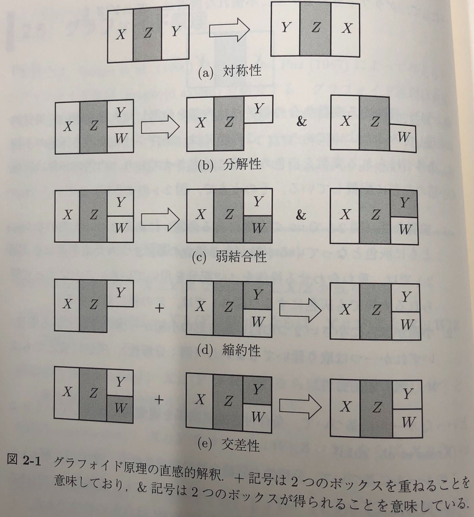

条件づける変数を灰色の小箱,条件づけられる変数を白色の小箱に対応させており,白色の小箱は灰色の小箱の左右に配置している.その上で,図2-1のように

1. $\rightarrow$の左側(前提条件)にある,2つの大箱のなかに共に灰色となっている小箱がある場合のみ,2つの大箱を重ねる(図2-1での$+$のこと)ことによって,得られる大箱でも灰色にする.
2. 小箱がさらに小さい2つの白い正方形の小箱から構成されている場合,いずれか1つは取り除いても良いし(例：分解性),灰色に変えても良い(例：弱結合性).